# Car Crash in UK

#### This is the second plot

[output not shown]

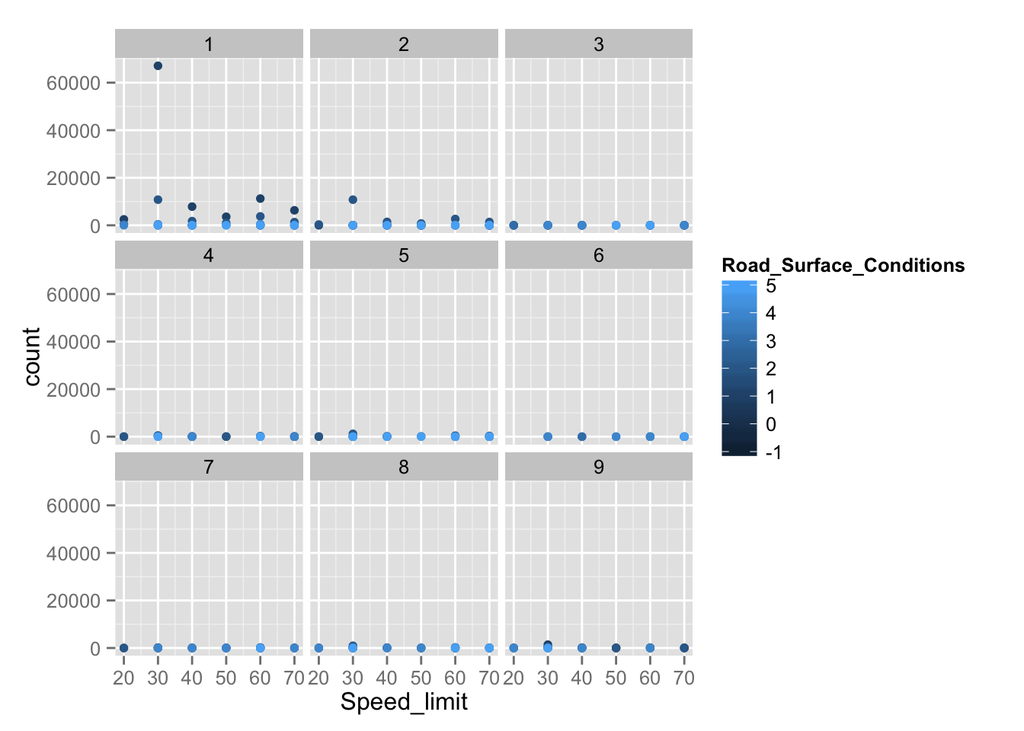

```r
source("../03 Data Visualization/Plot 2.R", echo = TRUE)
```

Plot 2: Accidents number ~ Weather Conditions, Road Surface Conditions and Speed limit In this plot, we try to look at the influences of different conditions, including weather, road surface and speed limit. From the graph, we see that most accidents were happened under weather condition 1, 2 and road surface condition -1, 0, and 1. However, most accidents happened at a speed limit of 30 which is contradicted to common sense. It might because that most roads has a speed limit of 30.

#### This is the third plot

[output not shown]

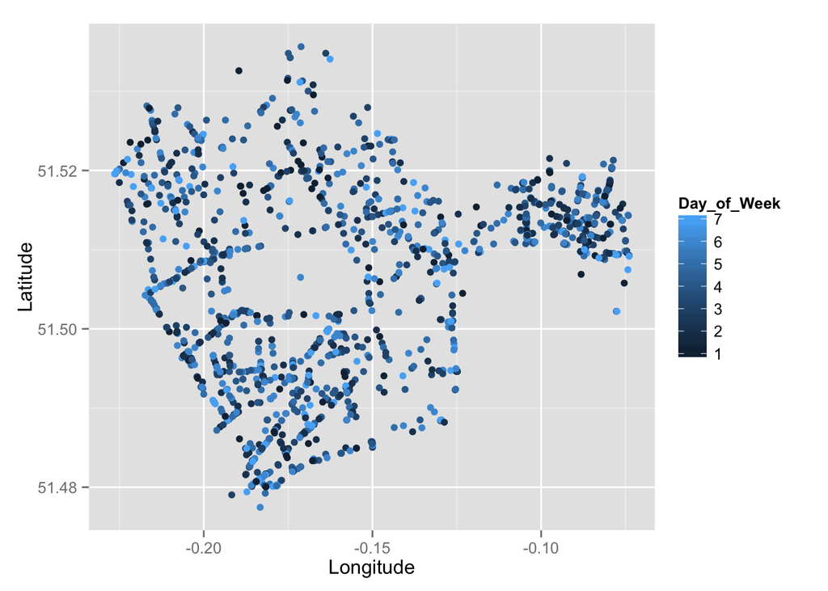

```r
source("../03 Data Visualization/Plot 3.R", echo = TRUE)
```

Plot 3: Geographical Distribution of Accidents As we mentioned before, there are too many records in the table so we select 1% of the accidents based on Accident Index. This plot is pretty straight forward, the more concentrated the dot is, the more accidents happened in that area.